# Coursework Report

*N* removed NAs: 2

*N* removed typo: 1

*N* removed <18: 24

*N* total clean: 123

| Group | *N* | *M*<sub>age</sub> | *M*<sub>rating</sub> |
| --- | --- | --- | --- |
| Control | 61 | 20.7 | 5.92 |
| Experim | 62 | 20.7 | 6.38 |

**Main analysis results**

*t*(121) = -3.51, *p* < .001

[interactive chart not shown]

[figure not shown]

[interactive chart not shown]

# Coursework Report

Analysing Data, Spring 2020

```
## # A tibble: 148 x 6
##    ID      AGE CONDITION ITEM_1 ITEM_2 ITEM_3
##    <fct> <dbl> <fct>      <dbl>  <dbl>  <dbl>
##  1 RAQY     21 control        5      3      8
##  2 DIYJ     20 control        6      8      6
##  3 LZJQ     22 control        8      6      7
##  4 NHFF     22 control        6      7      7
##  5 QLCI     20 control        5      6      5
##  6 OGQM     19 control        6      7      4
##  7 AWND     23 control        6      8      7
##  8 JYEK     17 control        5      4      6
##  9 KFRE     20 control        8      5      7
## 10 ZDTN     21 control        6      6      6
## # ... with 138 more rows
```

```
## [1] 24
```

```
## [1] 1
```

```
## # A tibble: 123 x 8
##    ID      AGE CONDITION ITEM_1 ITEM_2 ITEM_3 ITEM_comp na.rm
##    <fct> <dbl> <fct>      <dbl>  <dbl>  <dbl>     <dbl> <lgl>
##  1 RAQY     21 White          5      3      8      5.33 TRUE
##  2 DIYJ     20 White          6      8      6      6.67 TRUE
##  3 LZJQ     22 White          8      6      7      7    TRUE
##  4 NHFF     22 White          6      7      7      6.67 TRUE
##  5 QLCI     20 White          5      6      5      5.33 TRUE
##  6 OGQM     19 White          6      7      4      5.67 TRUE
##  7 AWND     23 White          6      8      7      7    TRUE
##  8 KFRE     20 White          8      5      7      6.67 TRUE
##  9 ZDTN     21 White          6      6      6      6    TRUE
## 10 GJEK     20 White          6      6      5      5.67 TRUE
## # ... with 113 more rows
```

[output not shown]

```
## # A tibble: 1 x 4
##    mean    sd   min   max
##   <dbl> <dbl> <dbl> <dbl>
## 1  20.7  1.83    18    26
```

```
## # A tibble: 2 x 5
##   CONDITION     n  perc ITEM_comp_mean ITEM_comp_sd
##   <fct>     <int> <dbl>          <dbl>        <dbl>
## 1 White        61  49.6           5.92        0.790
## 2 Red          62  50.4           6.38        0.651
```

[figure not shown]

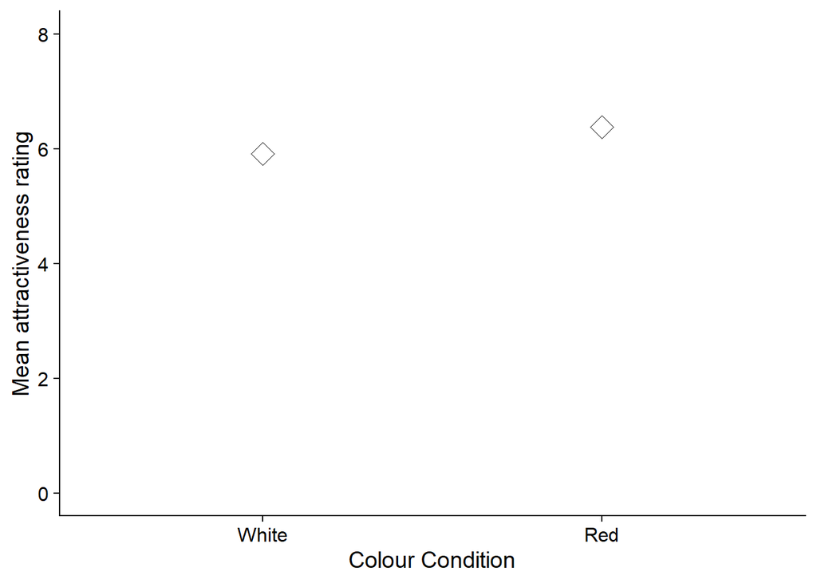

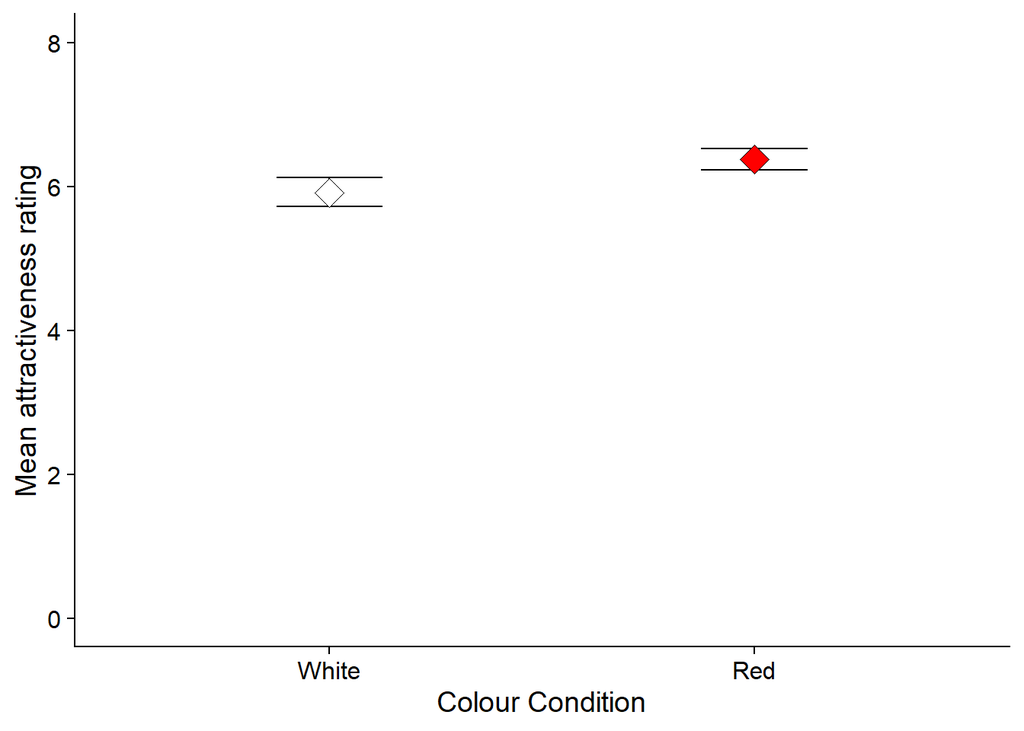

```
##
##  Two Sample t-test
##
## data:  ITEM_comp by CONDITION
## t = -4, df = 121, p-value = 0.0006
## alternative hypothesis: true difference in means is not equal to 0
## 95 percent confidence interval:
##  -0.717 -0.200
## sample estimates:
## mean in group White   mean in group Red
##                5.92                6.38
```

# Methods

## Participants

The study was conducted on a sample of 123 volunteers (*M*<sub>AGE</sub> 20.69, *SD*<sub>AGE</sub> = 1.83). The data were collected via lab participation. Data from 25 participants were excluded due to unlikely values of age and ethical implications.

## Design

The study investigated to what extent the effect of the colours red and white have on a female’s perceptions of male attractiveness. The red condition served as the experimental conditon whereas the white condition served as a control group. Therefore, an independent group design was utilised. The females observed a black and white photo of a man on a red or white background for 10 seconds and then reported their perceptions of attractivenes assessed via three face-valid items on a rating from 1-9 where 1 indicated ‘not at all attractive’ and 9 indiciated ‘extremely attractive.’ The first item and dependent variable asked was “how attractive do you think this person is?” The second asked “how pleasant is this person to look at?” The final asked “If I were to meet this person face-face, I would think he is attractive.” The photos in both conditions consisted of a head and upper torso shot of a Caucasian man with brown hair, in a plain shirt. The hypothesis predicts that the red frame will elicit a greater mean attractiveness rating by the participants and a *t*-test will be used to examine whether there will be a significant difference in the mean attractivenss rating of both conditions.

# Results

The purpose of this study was to examine whether the mean attractiveness rating for males was effected due to the frame being either red or white. The study utilised an indepdent *t* test and results illustrated a higher mean attractiveness rating in the red condition (*M* = 6.38) in comparison to the white condition (*M* = 5.92). The *t* test demonstrates that the difference in mean attractiveness ratings between both conditions were statistically significant (*M*~diff= 0.456 95% CI [-0.2, -0.72]). This supports our intended hypothesis in that the red condition generated a greater mean attractiveness rating (*t*(121) = -3.51, *p*= < .001).

# Discussion

In the present research, we reexamined the effect of red as reported by Eliot et al. (2010). According to their findings, woman perceive men presented in front of a red background or wearing a red shirt as being more attractive, more sexually desireable and higher in status. An important aspect of this research is our examination of the effect of red on a male’s perceived attractiveness. We replicated paradigm one used by Eliot et al having used the same three items to measure the dependent variable of perceived attractiveness. We used a 9 point scale where 1 indicated not at all attractive whereas 9 indicated extremely attractive. As per our proposed hypothesis, the participant’s judements did differ across both conditions in which the red frame generated a higher mean attractiveness rating in comparison to the white condition.This was similar to that of Eliot et al. In wider circumstances, the findings of the present study is significant as it integrates with previous work as evident in Re, Whitehead, Xiao and Perrett’s (2011) study. They showed that enhancing the redness on a male face increases the attractiveness of female perceivers. This can be supported through the idea that facial redness influences perceived healthiness and anger (Young et al., 2016), which suggests relative dominance (Hill and Barton, 2005). There has also been research that has suggested men find females dressed in red more attractive as opposed to other colours (Guéguen, 2012). Not only does this suggest red is an important predictor of attractiveness for both genders, but findings of our study contributes to the research area by strengthening the temporal validty of early research into the topic.

Despite present resarch is similar to that Elliot et al (2010), it is important to highlight other studies of red and attractiveness had generated oxymoranic findings. This was evident in a replication of experiment 1 of Eliot et al’s study, where participants in both colour conditions gave comparable ratings of percevied attractiveness. However, there was only a small difference between the average ratings and therefore was not statisically different (Hessinger et al., 2015). This decreases the validity of red as a significant predictor of attractiveness. Hesslinger et al (2015) additionally investigated apparel style as a predictor of attractiveness. They found that males who wore formal clothing were perceived as more attractive than men wearing casual apparel. This idea was further strengthend through the second finding of the study where men wearing formal attire were perceived to have higher status in comparison to the casual attire, regardless of the colour condition. These smarter clothing may indicate a busniess-like status and thus finanical security and thus has a stronger effect on attractiveness than red. Even Guéguen’s study (2012) on a male’s attractiveness to female hitch hikers in red was seen as biased due to the possibility of the female’s behaviour affecting the descision of the driver stopping or not. This means behaviour and clothing may be a more signifcant predictor of attractiveness than red, and further research must be conducted to enhance the validty of this idea.

One strength of the present study was the utilisation of an independent groups design. As the participants only took part in one condition, it removes the possibility of demand characteritics. This enhances the validty that red was a prominet predictor of male attractiveness and that was due to the manipulation of the independent variable- not the participants knowing the aim of the study. While removing the effects of order, a large sample size of our research additionally allowed a greater ability to detect an effect. It further allows better approximations of the population and a lower sampling error.

A further strength of the study was its use of labratory conditions. Since controlled and standardised conditions were used, it means the study can be replicated in the future to assess the findings reliability. It can allow researchers to develop further general laws upon red as a factor of attractiveness in other sexualalities in the future.

Nonetheless, the study also bores limitations. One weakness is there are many potential cofounding variables that play a role in male attractiveness, but were disregarded of. This was evident in Mehrabian and Blum’s, 1997 study which revealed that woman are attracted to physical strength and hence masculinity. As the 3 dependent variables in the present study did not measure this factor of attractiveness, but consisted of photo stimuli that showed the upper torso, it is possible this may have been a more significant predictor of attractiveness than the colour of the frame. To overcome this issue, future replication of this study may want to implement diffrent factor items related to physical attractiveness such as masculinity and sub items within such as shoulder width and chin size as developed by Mehrabian and Blum (1997). This is to avoid the problem of assumption that red is the only predictor of attractiveness during the study and better seek clarification on what actually determines this. This was moreover the case in the study of 19 heterosexual males who rated 40 attractive and non-attractive woman on a red or grey background (Young, 2015) Findings showed the relationship between red and sexual attraction was bounded by the woman’s baseline attractiveness and red only enhanced this perception. Meanwhile, red exerted no influence on non-attractive faces therefore indicating red only enunciates one’s already attractive features.

# References

Elliot, A. J., Niesta Kayser, D., Greitemeyer, T., Lichtenfeld, S., Gramzow, R. H., Maier, M. A., & Liu, H. (2010). Red, rank, and romance in women viewing men. Journal of Experimental Psychology: General, 139(3), 399–417. https://doi.org/10.1037/a0019689

Guéguen, N. (2012). Color and Women Attractiveness: When Red Clothed Women Are Perceived to Have More Intense Sexual Intent. The Journal of Social Psychology, 152(3), 261–265. https://doi.org/10.1080/00224545.2011.605398

Hesslinger, V. M., Goldbach, L., & Carbon, C.-C. (2015). Men in red: A reexamination of the red-attractiveness effect. Psychonomic Bulletin & Review, 22(4), 1142–1148. https://doi.org/10.3758/s13423-015-0866-8

Hill, R. A., & Barton, R. A. (2005). Red enhances human performance in contests. Nature, 435(7040), 293–293. https://doi.org/10.1038/435293a

Mehrabian, A., & Blum, J. S. (1997). Physical appearance, attractiveness, and the mediating role of emotions. Current Psychology, 16(1), 20–42. https://doi.org/10.1007/s12144-997-1013-0

Re, D. E., Whitehead, R. D., Xiao, D., & Perrett, D. I. (2011). Oxygenated-blood colour change thresholds for perceived facial redness, health, and attractiveness. PloS One, 6(3), e17859. https://doi.org/10.1371/journal.pone.0017859

Young, S. G. (2015). The effect of red on male perceptions of female attractiveness: Moderation by baseline attractiveness of female faces. European Journal of Social Psychology, 45(2), 146–151. https://doi.org/10.1002/ejsp.2098

Young, S. G., Thorstenson, C. A., & Pazda, A. D. (2016). Facial redness, expression, and masculinity influence perceptions of anger and health. Cognition and Emotion, 32(1), 49–60. https://doi.org/10.1080/02699931.2016.1273201

Zebrowitz, L. A., & Franklin, R. G. (2014). The Attractiveness Halo Effect and the Babyface Stereotype in Older and Younger Adults: Similarities, Own-Age Accentuation, and Older Adult Positivity Effects. Experimental Aging Research, 40(3), 375–393. https://doi.org/10.1080/0361073x.2014.897151